# Prediction Assignment

Kara Schimmelfing

1/18/2021

## Executive Summary

The goal of this analysis is to analyze the quality/correctness of barbell lifts using accelerometer data from the belt, forearm, arm and dumbbell of 6 participants. The training data for this project are available here:https://d396qusza40orc.cloudfront.net/predmachlearn/pml-training.csv The test data are available here: https://d396qusza40orc.cloudfront.net/predmachlearn/pml-testing.csv The 5 possible categories of quality/correctness are: A: exactly according to the specification B: throwing the elbows to the front C: lifting the dumbbell only halfway D: lowering the dumbbell only halfway E: throwing the hips to the front

##Analysis

```r
library(caret)
```

```r
library(rpart)
library(rpart.plot)
library(RColorBrewer)
library(rattle)
library(randomForest)
trainUrl <- "http://d396qusza40orc.cloudfront.net/predmachlearn/pml-training.csv"
testUrl <- "http://d396qusza40orc.cloudfront.net/predmachlearn/pml-testing.csv"
training <- read.csv(url(trainUrl), na.strings=c("NA","#DIV/0!",""))
testing <- read.csv(url(testUrl), na.strings=c("NA","#DIV/0!",""))
training$classe <- as.factor(training$classe)
```

Now the libraries you need are loaded and the data is in your local memory.

#Cleaning the Data After looking at the data (omitted here for length) there are several columns that have mostly NA values, we will remove those as well as variables that have very low variation.

```r
#clean training
NAindex <- apply(training,2,function(x) {sum(is.na(x))})
training <- training[,which(NAindex == 0)]
NAindex <- apply(testing,2,function(x) {sum(is.na(x))})
testing<- testing[,which(NAindex == 0)]

v <- which(lapply(training, class) %in% "numeric")

preObj <-preProcess(training[,v],method=c('knnImpute', 'center', 'scale'))
TrainDataClean <- predict(preObj, training[,v])
TrainDataClean$classe <- training$classe

ValidateDataClean <-predict(preObj,testing[,v])



#test for variation
NZV <- nearZeroVar(TrainDataClean)
NZV
```

```
## integer(0)
```

Note there was sufficient variation in all columns.

#Data Partitioning

```r
set.seed(23456)
inTrain <- createDataPartition(TrainDataClean$classe, p = 0.7, list = FALSE)
TrainData <- TrainDataClean[inTrain, ]
TestData <- TrainDataClean[-inTrain, ]
dim(TrainData)
```

```
## [1] 13737    28
```

# Decision Tree

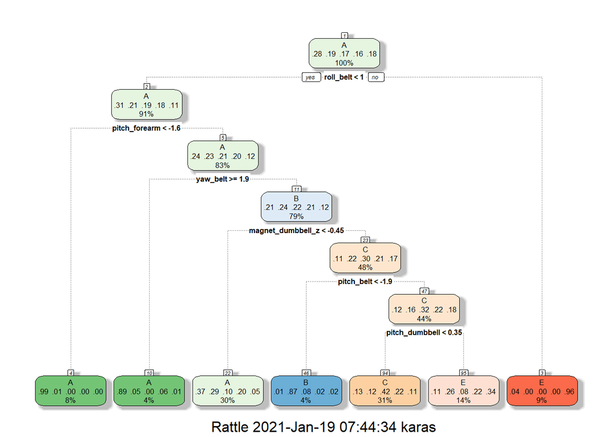

```r
modFitA1 <- train(classe~., data=TrainData, method="rpart")
fancyRpartPlot(modFitA1$finalModel)
```

Prediction and testing

```r
predictionsA1 <- predict(modFitA1, newdata=TestData )
confusionMatrix(table(predictionsA1, TestData$classe))
```

```
## Confusion Matrix and Statistics
##
##
## predictionsA1    A    B    C    D    E
##             A 1322  522  198  391   96
##             B    7  201   34    8    9
##             C  224  194  734  401  202
##             D    0    0    0    0    0
##             E  121  222   60  164  775
##
## Overall Statistics
##
##                Accuracy : 0.5152
##                  95% CI : (0.5023, 0.5281)
##     No Information Rate : 0.2845
##     P-Value [Acc > NIR] : < 2.2e-16
##
##                   Kappa : 0.3747
##
##  Mcnemar's Test P-Value : < 2.2e-16
##
## Statistics by Class:
##
##                      Class: A Class: B Class: C Class: D Class: E
## Sensitivity            0.7897  0.17647   0.7154   0.0000   0.7163
## Specificity            0.7134  0.98778   0.7899   1.0000   0.8819
## Pos Pred Value         0.5227  0.77606   0.4182      NaN   0.5775
## Neg Pred Value         0.8951  0.83327   0.9293   0.8362   0.9324
## Prevalence             0.2845  0.19354   0.1743   0.1638   0.1839
## Detection Rate         0.2246  0.03415   0.1247   0.0000   0.1317
## Detection Prevalence   0.4297  0.04401   0.2982   0.0000   0.2280
## Balanced Accuracy      0.7515  0.58212   0.7526   0.5000   0.7991
```

# Random Forest

Prediction and Testing

```r
RF_Model <-randomForest(classe ~. , data=TrainData)
predictionsB1 <- predict(RF_Model, TestData)
confusionMatrix(predictionsB1, as.factor(TestData$classe))
```

```
## Confusion Matrix and Statistics
##
##           Reference
## Prediction    A    B    C    D    E
##          A 1673    4    0    0    0
##          B    1 1131    4    0    0
##          C    0    4 1011    5    1
##          D    0    0   11  958    5
##          E    0    0    0    1 1076
##
## Overall Statistics
##
##                Accuracy : 0.9939
##                  95% CI : (0.9915, 0.9957)
##     No Information Rate : 0.2845
##     P-Value [Acc > NIR] : < 2.2e-16
##
##                   Kappa : 0.9923
##
##  Mcnemar's Test P-Value : NA
##
## Statistics by Class:
##
##                      Class: A Class: B Class: C Class: D Class: E
## Sensitivity            0.9994   0.9930   0.9854   0.9938   0.9945
## Specificity            0.9991   0.9989   0.9979   0.9967   0.9998
## Pos Pred Value         0.9976   0.9956   0.9902   0.9836   0.9991
## Neg Pred Value         0.9998   0.9983   0.9969   0.9988   0.9988
## Prevalence             0.2845   0.1935   0.1743   0.1638   0.1839
## Detection Rate         0.2843   0.1922   0.1718   0.1628   0.1828
## Detection Prevalence   0.2850   0.1930   0.1735   0.1655   0.1830
## Balanced Accuracy      0.9992   0.9960   0.9917   0.9953   0.9971
```

Better results then previous Decision Tree

#Predictions on the verification data We are using Random Forest because it gave us the best result.

```r
Prediction_Test <- predict(RF_Model,newdata=ValidateDataClean)
Prediction_Test
```

```
##  1  2  3  4  5  6  7  8  9 10 11 12 13 14 15 16 17 18 19 20
##  B  A  B  A  A  E  D  B  A  A  B  C  B  A  E  E  A  B  B  B
## Levels: A B C D E
```